# Production industrielle mensuelle de glaces et sorbets (1990-2023)

### Question 3

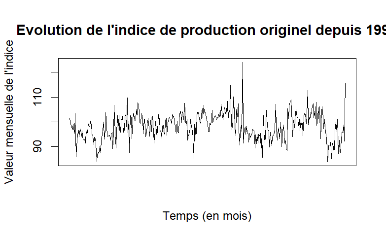

```r
# Indice originel
plot(choco, xaxt = "n", xlab ="Temps (en mois)", ylab = "Valeur mensuelle de l'indice", main = "Evolution de l'indice de production originel depuis 1990")
```

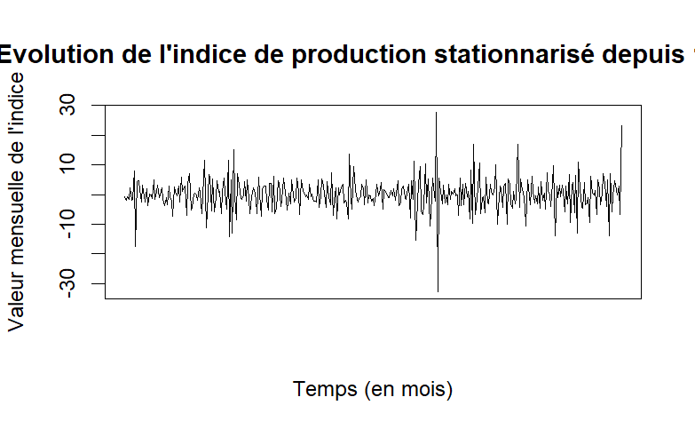

```r
# Indice stationnarisé

plot(choco2, xaxt = "n", xlab ="Temps (en mois)", ylab = "Valeur mensuelle de l'indice", main = "Evolution de l'indice de production stationnarisé depuis 1990")
```

### Question 4

[figure not shown]

```r
acf(choco2)
```

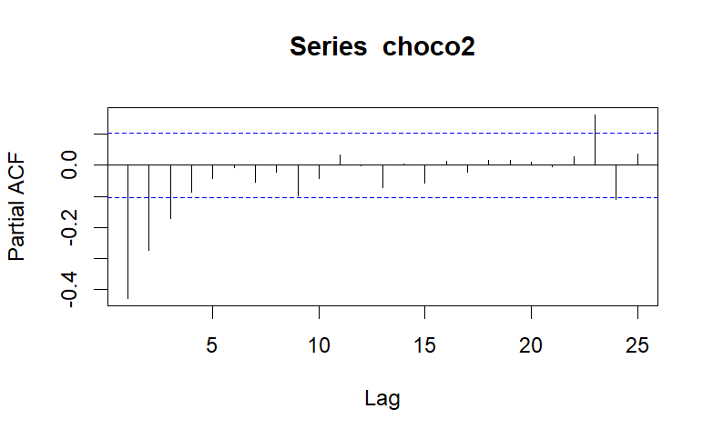

```r
pacf(choco2)
```

On garde les ordres maximuaux $p^* = 3$ et $q^* = 2$. Testons les combinaisons $(p,q)$ où $0 \leq p \leq p^*$ et $0 \leq q \leq q^*$.

```r
p_etoile = 3
q_etoile = 2

pqs <- expand.grid(0:p_etoile,0:q_etoile) # Combinaisons possibles de p<=p* et q<=q*
mat <- matrix(NA, nrow=p_etoile+1, ncol=q_etoile+1)
rownames(mat) <- paste0("p=",0:p_etoile) # Renomme les lignes
colnames(mat) <- paste0("q=",0:q_etoile) # Renomme les colonnes
AICs <- mat # Matrice ou assigner les AIC
BICs <- mat # Matrice ou assigner les BIC
for (row in 1:dim(pqs)[1]){
  p <- pqs[row,1]
  q <- pqs[row,2]
  estim <- try(arima(choco2,c(p, 0, q), include.mean=F)) # Tente d'estimer l'ARMA
  AICs[p+1,q+1] <- if (class(estim)=="try-error") NA else estim$aic
  BICs[p+1,q+1] <- if (class(estim)=="try-error") NA else BIC(estim)
}
```

On regarde quelles valeurs de $(p,q)$ minimisent l’AIC et le BIC.

```r
AICs == min(AICs)
```

```
      q=0   q=1   q=2
p=0 FALSE FALSE FALSE
p=1 FALSE FALSE  TRUE
p=2 FALSE FALSE FALSE
p=3 FALSE FALSE FALSE
```

```r
BICs == min(BICs)
```

```
      q=0   q=1   q=2
p=0 FALSE  TRUE FALSE
p=1 FALSE FALSE FALSE
p=2 FALSE FALSE FALSE
p=3 FALSE FALSE FALSE
```

On garde donc les modèles ARMA(1, 2) et ARMA(0, 1).

```r
arima102 <- arima(choco2,c(1,0,2),include.mean=F)
arima001 <- arima(choco2,c(0,0,1),include.mean=F)
```

On vérifie que les deux modèles sont bien ajustés.

```r
arima102
```

```
Call:
arima(x = choco2, order = c(1, 0, 2), include.mean = F)

Coefficients:
         ar1      ma1     ma2
      0.9139  -1.6453  0.6453
s.e.  0.0342   0.0653  0.0649

sigma^2 estimated as 21.04:  log likelihood = -1063.99,  aic = 2135.98
```

```r
arima001
```

```
Call:
arima(x = choco2, order = c(0, 0, 1), include.mean = F)

Coefficients:
          ma1
      -0.7322
s.e.   0.0447

sigma^2 estimated as 21.8:  log likelihood = -1068.93,  aic = 2141.86
```

Pour vérifier cela, on regarde si AR et le MA le plus grand de chaque modèle est significatif. Pour cela, on regarde si la valeur absolue du coefficient divisée par l’écart-type est plus grande que 1.96 (ce qui correspond au seuil de 5%) : $\frac{|Coeff|}{se(Coeff)} \ge 1.96$.

Concernant l’ARMA(1, 2), AR(1) et MA(2) sont tous les deux significatifs car $\frac{0.9139}{0.0342} \simeq 26.72 \ge 1.96$ et $\frac{0.6453}{0.0649} \simeq 9.94 \ge 1.96$.Donc le modèle est bien ajusté.

L’ARMA(0, 1) ne prend en compte que que MA(1) donc on va regarder ce coefficient seulement. Or, $\frac{|-0.7322|}{0.0447} \simeq 16.38 \ge 1.96$. Donc l’ARMA(0, 1) est bien ajusté.

Nous allons maintenant vérifier si ces modèles sont susceptibles de présenter de l’autocorrélation (On prend $fitdf = p+q$).

```r
#install.packages("fUnitRoots")
require("fUnitRoots")
```

Pour l’ARMA(1, 2) :

```r
Qtests(arima102$residuals,20,fitdf=3)
```

```
      lag      pval
 [1,]   1        NA
 [2,]   2        NA
 [3,]   3        NA
 [4,]   4 0.4824044
 [5,]   5 0.7811763
 [6,]   6 0.8910427
 [7,]   7 0.8157325
 [8,]   8 0.9055844
 [9,]   9 0.9121785
[10,]  10 0.7901616
[11,]  11 0.7941658
[12,]  12 0.8014378
[13,]  13 0.7708642
[14,]  14 0.8120455
[15,]  15 0.8583173
[16,]  16 0.8461977
[17,]  17 0.8907869
[18,]  18 0.8990984
[19,]  19 0.9145627
[20,]  20 0.9324906
```

On ne rejette pas $H_0$ et l’absence de corrélation.Donc l’ARMA(1, 2) paraît valide.

Pour l’ARMA(0, 1) :

```r
Qtests(arima001$residuals,20,fitdf=1)
```

```
      lag      pval
 [1,]   1        NA
 [2,]   2 0.4700417
 [3,]   3 0.7667304
 [4,]   4 0.9025284
 [5,]   5 0.9439162
 [6,]   6 0.9056300
 [7,]   7 0.7006264
 [8,]   8 0.7577959
 [9,]   9 0.6916572
[10,]  10 0.7035659
[11,]  11 0.7710588
[12,]  12 0.7041430
[13,]  13 0.5913742
[14,]  14 0.6689876
[15,]  15 0.7061732
[16,]  16 0.7318438
[17,]  17 0.7877226
[18,]  18 0.8131196
[19,]  19 0.8399142
[20,]  20 0.8689194
```

On ne peut pas rejeter l’absence de corrélation ici non plus donc l’ARMA(0, 1) semble valide.

Départageons les deux modèles en regardant lequel des deux est le plus efficace.

```r
adj_r2 <- function(model){
  ss_res <- sum(model$residuals^2)
  ss_tot <- sum(choco2[-c(1:max(p,q))]^2)
  p <- model$arma[1]
  q <- model$arma[2]
  n <- model$nobs-max(p,q)
  adj_r2 <- 1-(ss_res/(n-p-q-1))/(ss_tot/(n-1))
  return(adj_r2)
}
adj_r2(arima102)
```

```
[1] 0.3292794
```

```r
adj_r2(arima001)
```

```
[1] 0.3090064
```

L’ARMA(1, 2) a le meilleur R² ajusté, c’est donc celui que nous sélectionnons.

Moyenne temporelle de la série différenciée (choco2):

```r
mean(choco2)
```

```
[1] 0.03872576
```

### Question 5

On peut vérifier pour être sur que l’ARIMA(1, 1, 2) est meilleur que l’ARIMA(0, 1, 1).

```r
arima112 <- arima(choco,c(1,1,2),include.mean=F)
arima011 <- arima(choco,c(0,1,1),include.mean=F)

adj_r2(arima112)
```

```
[1] 0.3292785
```

```r
adj_r2(arima011)
```

```
[1] 0.3090055
```

### Question 7

On teste la normalité des résidus.

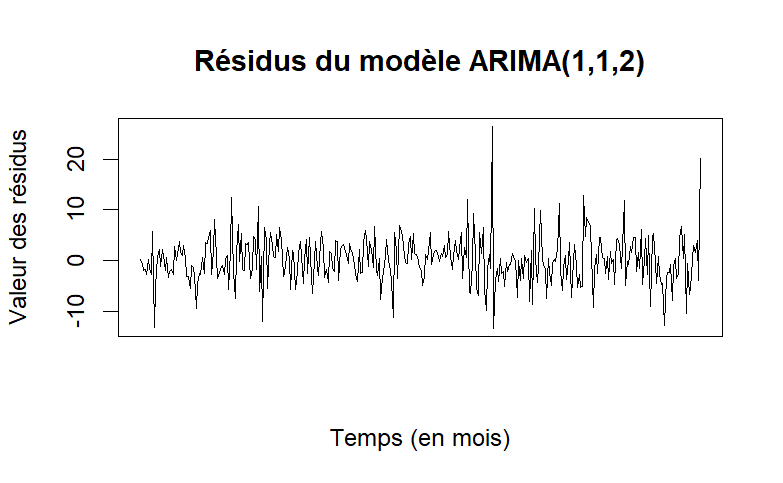

```r
plot(arima112$residuals, xaxt = "n", xlab ="Temps (en mois)", ylab = "Valeur des résidus", main = "Résidus du modèle ARIMA(1,1,2)")
```

[output not shown]

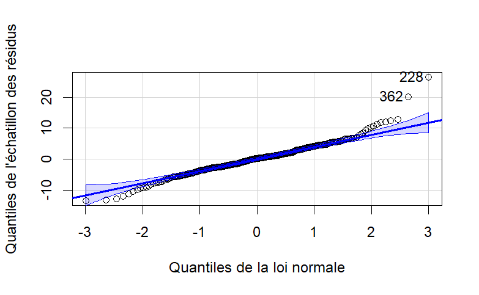

```r
library(car)
qqPlot(arima112$residuals, xlab ="Quantiles de la loi normale", ylab = "Quantiles de l'échatillon des résidus")
```

### Question 8

On utilise la librairie “forecast” pour les prédictions, “dplyr”, “ggplot2” et “reshape2” pour les représenter.

```r
#install.packages("forecast")
require(forecast)
library(dplyr)
library(ggplot2)
library(reshape2)
```

On effectue la prédiction pour deux périodes supplémentaires au seuil de 95%. On récupère la prédiction et les intervalles de confiance.

```r
pred_arima112=forecast(arima112,h=2,level=95)

prediction = zoo(pred_arima112$mean)
prediction_inf= zoo(pred_arima112$lower)
prediction_sup= zoo(pred_arima112$upper)
```

Avant de tracer la prédiction avec ggplot, on prépare un tableau contenant une colonne avec les indices de la série et ses prédictions et d’autres colonnes avec les bornes des intervalles de confiance.

```r
SERIE <-  data.frame(choco)
SERIE["Temps"] <-  as.numeric(rownames(SERIE))

PREDICTIONS <-data.frame(prediction)
PREDICTIONS["Temps"] <- as.numeric(rownames(PREDICTIONS))

PRED_SERIE = merge(x=SERIE, y=PREDICTIONS, by="Temps", all=TRUE)
PRED_SERIE_MELTED <- melt(PRED_SERIE ,  id.vars = 'Temps', variable.name = 'series')

CONFIANCE <- data.frame(prediction_inf, prediction_sup)
CONFIANCE["Temps"] <- as.numeric(rownames(CONFIANCE))

ALL <-  merge(x=PRED_SERIE_MELTED, y=CONFIANCE, by="Temps", all=TRUE)
names(ALL) <- c("Temps", "series", "value", "inf", "sup")
```

On trace la série et ses prédictions avec ggplot, on utilise des barres d’erreur pour représenter l’intervalle de confiance.

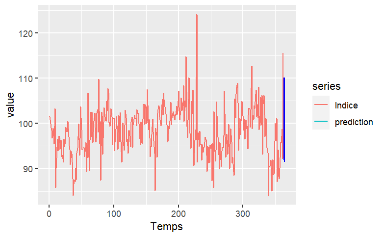

```r
ggplot(ALL, aes(Temps, value)) + geom_line(aes(colour = series)) + geom_errorbar(aes(ymin = inf, ymax = sup), width = 0.5, color = "blue")
```

Les prédictions sont peu visibles car il y a trop de valeurs, on se concentre uniquement sur la fin de la série.

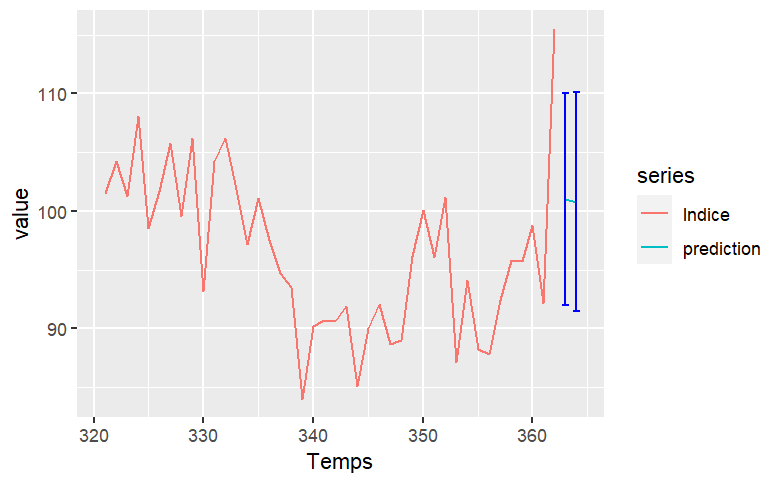

```r
ALL_red <- ALL[ALL$Temps > 320, ]
ggplot(ALL_red, aes(Temps, value)) + geom_line(aes(colour = series)) + geom_errorbar(aes(ymin = inf, ymax = sup), width = 0.7, color = "blue")
```

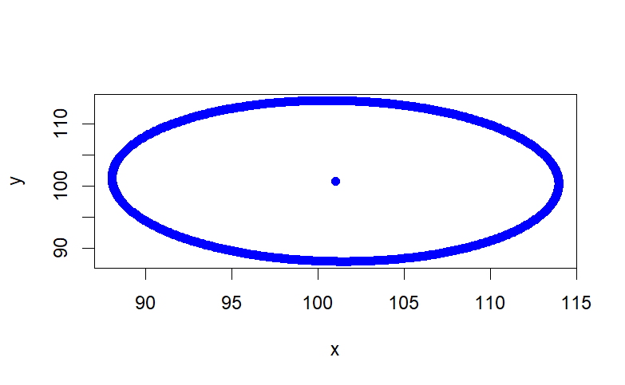

```r
xc <- as.numeric(prediction[1]) # center x
yc <- as.numeric(prediction[2]) # y
a <- as.numeric(prediction_sup[1])-as.numeric(prediction[1]) # major axis length
b <- as.numeric(prediction_sup[2])-as.numeric(prediction[2]) # minor axis length
phi <- pi/4 # angle

t <- seq(0, 2*pi, 0.01)
x <- xc + a*cos(t) - b*sin(t)
y <- yc + a*cos(t) + b*sin(t)
x <- c(x,xc)
y <- c(y,yc)
plot(x,y,pch=19, col='blue')
```